# SigFun: a functional analysis tool for signature.

2025-05-02

#### Abstract

Biomarker exploration has become central to advancing clinical diagnostics and therapeutic decision-making, with a notable shift from single-gene markers to multigene signatures that better capture the complexity of biological processes. For example, in breast cancer, multigene signatures such as MammaPrint and Oncotype DX have been robustly validated and are now widely used to improve risk stratification and personalize adjuvant chemotherapy decisions. However, functional interpretation of these signatures remains challenging, especially when gene sets are small and traditional enrichment analyses are not feasible. To address this, we developed SigFun, a novel analytical framework that leverages transcriptome data to map multigene signatures ontothe whole genome, irrespective of whether signatures are binary or continuous. SigFun overcomes this by mapping signature genes to the entire transcriptome using correlation-based scoring or logistic regression. This creates a genome-wide association profile that preserves biological context while amplifying signal detection capability. By transforming signatures into transcriptome-wide quantitative traits, SigFun unlocks functional enrichment analysis even for signatures with as few as 5-10 genes — a capability we term scale-bridging analysis. This innovation allows researchers to uncover pathway-level insights from clinically validated but mechanistically opaque signatures, bridging the gap between biomarker utility and biological understanding.

#### Package

SigFun 0.99.0

# 1 Introduction

## 1.1 Biomarker exploration

Biomarker exploration in clinical practice represents a pivotal area ofclinical research, as it holds significant potential for enhancing diagnostic and therapeutic strategies. The trend in biomarker exploration isshifting towards the use of multi-gene signatures, which generally outperform single-gene markers due to their ability to provide a more comprehensive view of complex biological processes. This approach has been successfully applied in clinical settings, where several multi-gene signatures have been implemented to guide treatment decisions. Notable examples include MammaPrint, a 70-gene signature used in breast cancer prognosis, and OncoTypeDX, a 21-gene signature also employed in breast cancer management. These signatures have demonstrated the utility of multi-gene biomarkers in improving patient outcomes by offering more precise risk assessments and personalized treatment plans.

## 1.2 Current limitation in deciphering multi-gene signatures

Current limitations in the functional analysis of multi-gene signatures pose significant challenges in fully understanding their biological implications. While it is possible to individually interpret each gene within a signature, a systematic approach to deciphering these multi-gene signatures remains elusive. This issue is particularly pronounced for signatures consisting of a small set of genes, where conventional methods such as Over-Representation Analysis (ORA) and Gene Set Enrichment Analysis (GSEA) become infeasible. Consequently, this limitation hinders further advanced analysis of the signatures, particularly in elucidating their related biological functions or underlying mechanisms, thereby obstructing a deeper understanding of their roles in complex biological processes.

## 1.3 SigFun: scale-bridge a signature to genome scale

SigFun is a novel solution designed to address the challenges associated with functional analysis of multi-gene signatures. SigFun leverages transcriptome data as a surrogate, allowing users to evaluate their signatures regardless of the size. Furthermore, the versatility of SigFun also allowing users to evaluate their signatures in various format types including binary values, such as the high or low risk classifications provided by MammaPrint, or continuous values, like prognostic risk scores.

In the following tutorial, we will utilize a specific study and its corresponding dataset (GSE181574) as an illustrative example to demonstrate how SigFun can be employed to decipher the biologically relevant functions associated with the MammaPrint signature.

# 2 Installation

Here is the procedures of running the **SigFun** package on your system. We assume that you have already installed the R program (see the R project at http://www.r-project.org and are familiar with it. You need to have R 4.5.0 or a later version installed for running SigFun.

Our package is available at the Bioconductor repository [http://www.bioconductor.org] (http://www.bioconductor.org). To install our package, first, you need to install the core Bioconductor packages. If you have already installed the Bioconductor packages on your system, you can skip the following step below.

```r
if (!requireNamespace("BiocManager", quietly=TRUE))
    install.packages("BiocManager")
BiocManager::install()
```

Once the core Bioconductor packages have been installed, we can begin the installation of the SigFun package.

```r
if (!requireNamespace("BiocManager", quietly=TRUE))
    install.packages("BiocManager")
BiocManager::install("SigFun")
```

After conducting the above step, now you can load in our package and start using it!

```r
library(SigFun)
library(BiocStyle)
library(S4Vectors)
library(dplyr)
library(utils)
```

# 3 Quick start with demo data

We use GSE181574 to demonstrate how SigFun can help users to analyze biologicalfunctions related to a signature. GSE181574 is the gene expression profile of a breast cancer cohort which used a 70-gene signature to classify patients as high-risk or low-risk in tumor progression. Although the related biological function of every single gene can be annotated, respectively, a systematicallyfunctional assessment connecting the signature to tumor progression is not easy.As mentioned in the Introduction, SigFun takes the whole transcriptome expression as the surrogate to decipher related biological functions of the signature.

## 3.1 Demo data description

Let’s load the demo data. There are two objects: (1) SE_GSE181574 (the expression profile and patient signature score) and (2) pathway.all (biological function and corresponding genes). The main input is a S4 class SummariedExperiment object:

```r
data("demo_GSE181574")
slotNames(SE_GSE181574)
```

```
## [1] "colData"         "assays"          "NAMES"           "elementMetadata"
## [5] "metadata"
```

The other input is a list which contains biological functions and their corresponding genes. In this demo, the pathway.all was obtained from MsigDB which containing at least: * GO-biological process (GOBP) * GO-molecular function (GOMF) * GO-cellular Component (GOCC) * Kyoto Encyclopedia of Genes and Genomes (KEGG) * MSigDB HALLMARK (HALLMARK) * WikiPathways (WP) * REACTOME Pathways (REACTOME) * Signaling related Pathways (SIGNALING)

Although we provide a basic ontology database, users can replace it with their own gene set to align with their own interest. To see the list structure:

```r
head(pathways.all)
```

```
## $HALLMARK_TNFA_SIGNALING_VIA_NFKB
##   [1] "JUNB"     "CXCL2"    "ATF3"     "NFKBIA"   "TNFAIP3"  "PTGS2"
##   [7] "CXCL1"    "IER3"     "CD83"     "CCL20"    "CXCL3"    "MAFF"
##  [13] "NFKB2"    "TNFAIP2"  "HBEGF"    "KLF6"     "BIRC3"    "PLAUR"
##  [19] "ZFP36"    "ICAM1"    "JUN"      "EGR3"     "IL1B"     "BCL2A1"
##  [25] "PPP1R15A" "ZC3H12A"  "SOD2"     "NR4A2"    "IL1A"     "RELB"
##  [31] "TRAF1"    "BTG2"     "DUSP1"    "MAP3K8"   "ETS2"     "F3"
##  [37] "SDC4"     "EGR1"     "IL6"      "TNF"      "KDM6B"    "NFKB1"
##  [43] "LIF"      "PTX3"     "FOSL1"    "NR4A1"    "JAG1"     "CCL4"
##  [49] "GCH1"     "CCL2"     "RCAN1"    "DUSP2"    "EHD1"     "IER2"
##  [55] "REL"      "CFLAR"    "RIPK2"    "NFKBIE"   "NR4A3"    "PHLDA1"
##  [61] "IER5"     "TNFSF9"   "GEM"      "GADD45A"  "CXCL10"   "PLK2"
##  [67] "BHLHE40"  "EGR2"     "SOCS3"    "SLC2A6"   "PTGER4"   "DUSP5"
##  [73] "SERPINB2" "NFIL3"    "SERPINE1" "TRIB1"    "TIPARP"   "RELA"
##  [79] "BIRC2"    "CXCL6"    "LITAF"    "TNFAIP6"  "CD44"     "INHBA"
```

[output cut: 126 more lines]

## 3.2 SigFun one-click command

To analyze the signature and obtain related biological function, we can just use sig2Fun (signature-to-functions) by setting corresponding parameters. In this demonstration, the MammaPrint signature classify patients into high- and low-risk (a binary variable). Consequently, the proper statistical method is a logistic regression model (cor.method=“logit”) and the signature does not need to be normalized (Z.transform=FALSE).

```r
# Run signature-to-function analysis
res <- sig2Fun(
    SE_data=SE_GSE181574,
    ranking.method="stat",
    species="human",
    cor.method="logit",
    pathways_all=pathways.all,
    topN=10,
    Z.transform=FALSE,
    significat_type="pval",
    strings=c("HALLMARK")
)
```

## 3.3 Visualization of results

Users can visualize top signature-related function. The plot object(s) dependent on the parameter “strings” assigned in the sig2Fun function. For example, when we assign strings=c(“HALLMARK”) and topN=10. sig2Fun will plot top 10 functions with strings containg “HALLMARK”. On the other hand, if you assign topN=5 and strings=“GOBP”, sig2Fun will plot top 5 functions with strings containg “BOBP”. Currently, we provide two ways of visualization: (1) barplot and (2) heatmap.

### 3.3.1 Visualization 1: barplot

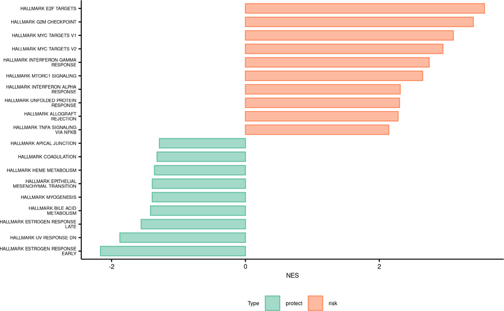

```r
res$barplots[["HALLMARK"]]
```

### 3.3.2 Visualization 2: functional enrichment heatmap

There are four columns in the heatmap (from left to right): 1. NES 2. p-value 2. Score distribution 3. Name of function

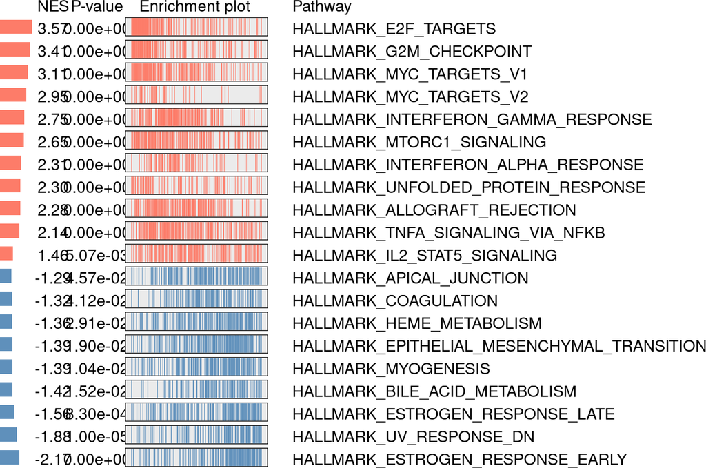

```r
res$heatmap[["HALLMARK"]]
```

# 4 Analyze your own dataset step-by-step in SigFun

Usually, users’ raw datasets are in matrix or data.frame format. This tutorial will help users to construct their SummarizedExperiment objectusing their own datasets and run analysis step-by-step instead of one-click for more customized options.

## 4.1 Input data: Constructing SummarizedExperiment object

First, we dissect the demo data to inspect their structures. ** assay: your expression profile (sample in column and gene in row) ** colData: signature score (the corresponding score assigned to each sample) ** rowData: gene annotation (ensemble ID and official gene symbol lookup table) Note: In rowData, the “ensg_id” must align with the row name of GENE_MAT and “gene_symbol” must align with the gene ID system in pathway.all mentioned in the Demo data description.

```r
# expression profile
GENE_MAT <- as.data.frame(SummarizedExperiment::assay(SE_GSE181574))
GENE_MAT[1:5,1:5]
```

```
##                 112606 122287 123660 125130 127791
## ENSG00000288642 6.3670 5.6872 6.3694 4.6826 5.9389
## ENSG00000288611 6.6319 6.7997 7.8160 6.4822 6.9639
## ENSG00000288596 8.8999 8.2503 7.2915 7.4501 7.3911
## ENSG00000288547 6.5069 5.1557 6.6837 4.7711 5.3696
## ENSG00000285975 6.4584 5.7035 6.9725 5.7816 6.8409
```

```r
# Signature score
SIG_MAT <- as.data.frame(SummarizedExperiment::colData(SE_GSE181574))
head(SIG_MAT)
```

```
##        sample_id value
## 112606    112606     0
## 122287    122287     1
## 123660    123660     0
## 125130    125130     1
## 127791    127791     0
## 128051    128051     0
```

```r
# gene symbol mapping table
mapping <- as.data.frame(SummarizedExperiment::rowData(SE_GSE181574))
head(mapping)
```

```
##                         ensg_id gene_symbol   gene_biotype
## ENSG00000288642 ENSG00000288642        CDR1 protein_coding
## ENSG00000288611 ENSG00000288611      NPBWR1 protein_coding
## ENSG00000288596 ENSG00000288596     C8orf44 protein_coding
## ENSG00000288547 ENSG00000288547     C3orf36 protein_coding
## ENSG00000285975 ENSG00000285975    FAM90A7P protein_coding
## ENSG00000285294 ENSG00000285294   LINC00842         lncRNA
```

Now, we will construct SummarizedExperiment object from the three raw datasets and users can just replace them using their own dataset. We will use the `SummarizedExperiment` function from *SummarizedExperiment*. Follow the command below to create this object.

```r
assay.data <- GENE_MAT
rowData.data <- mapping
colData.data <- SIG_MAT

SE_data <- SummarizedExperiment::SummarizedExperiment(
    assays=list(abundance=as.matrix(assay.data)),
    rowData=S4Vectors::DataFrame(rowData.data,
    row.names=rowData.data$ensg_id), colData=colData.data)

SE_data
```

```
## class: SummarizedExperiment
## dim: 17341 127
## metadata(0):
## assays(1): abundance
## rownames(17341): ENSG00000288642 ENSG00000288611 ... ENSG00000000005
##   ENSG00000000003
## rowData names(3): ensg_id gene_symbol gene_biotype
## colnames(127): 112606 122287 ... 995480 999264
## colData names(2): sample_id value
```

## 4.2 sigCor: run gene correlation with signature patterns

sigCor is the scale-bridging function which bridges the signature to whole genome scale.

```r
# Method for calculate correlation
# logit for binary signature
# pearson or spearman for continuous data
cor.method="logit"
SE_data.cor <- sigCor(
    SE_data=SE_data,
    cor.method=cor.method,
    Z.transform=FALSE)
```

## 4.3 sig2GSEA: Run fGSEA using gene ranking values load corRES

The whole genome score of the signature could be assessed by sig2GSEA function.

```r
# Ranking method for GSEA. (stat for statistics or pval for p-value)
ranking.method="stat"
SE_data.fgsea <- sig2GSEA(
    SE_data.cor=SE_data.cor,
    ranking.method=ranking.method,
    pathways.all=pathways.all)
```

## 4.4 Visualization

### 4.4.1 barplot

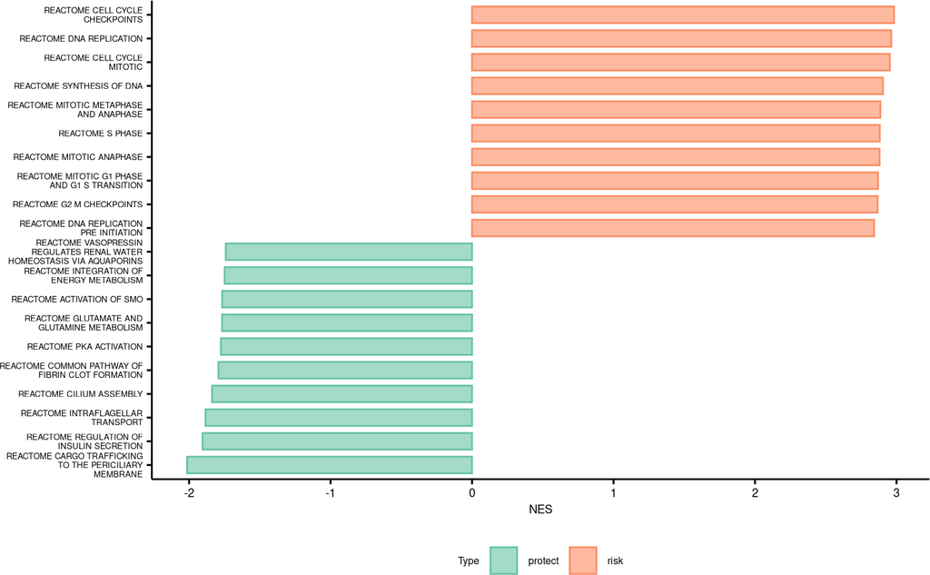

```r
strings=c("REACTOME")
barplots <- plot_bar(
    SE_data.fgsea=SE_data.fgsea,
    topN=10,
    significat_type="pval",
    strings=strings)
barplots
```

### 4.4.2 heatmap

#### 4.4.2.1 REACTOME Pathways

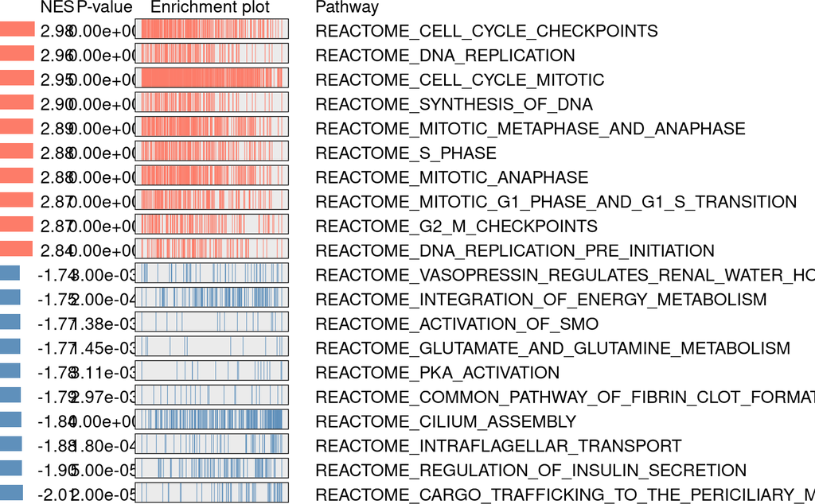

```r
heatmap <- plot_heat(
    SE_data.fgsea=SE_data.fgsea,
    strings="REACTOME",
    significat_type="pval",
    topN=10,
    pathways.all=pathways.all,
    ranking.method=ranking.method)
heatmap
```

#### 4.4.2.2 Kyoto Encyclopedia of Genes and Genomes

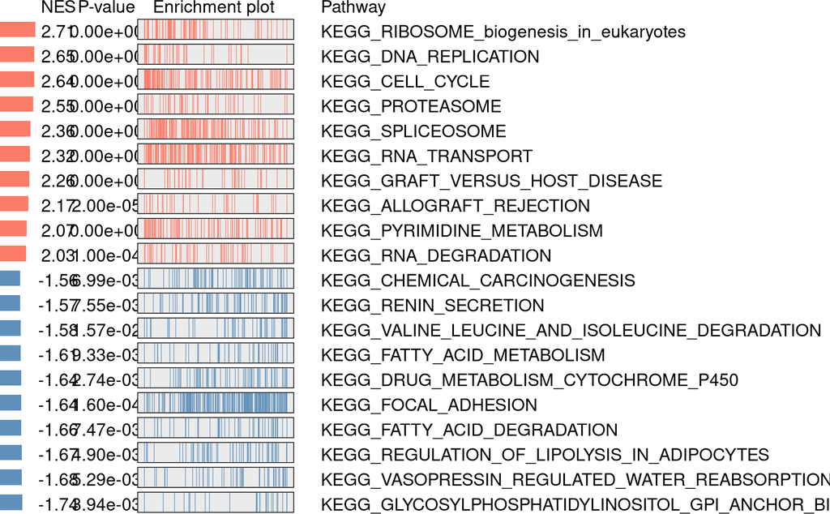

```r
heatmap <- plot_heat(
    SE_data.fgsea=SE_data.fgsea,
    strings="KEGG",
    significat_type="pval",
    topN=10,
    pathways.all=pathways.all,
    ranking.method=ranking.method)
heatmap
```

#### 4.4.2.3 WikiPathways

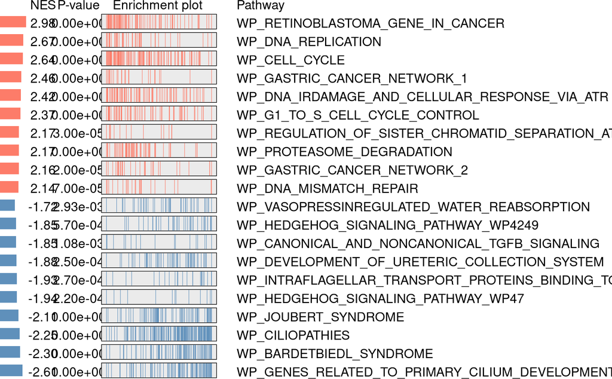

```r
heatmap <- plot_heat(
    SE_data.fgsea=SE_data.fgsea,
    strings="WP",
    significat_type="pval",
    topN=10,
    pathways.all=pathways.all,
    ranking.method=ranking.method)
heatmap
```

#### 4.4.2.4 Gene Ontology: biological process

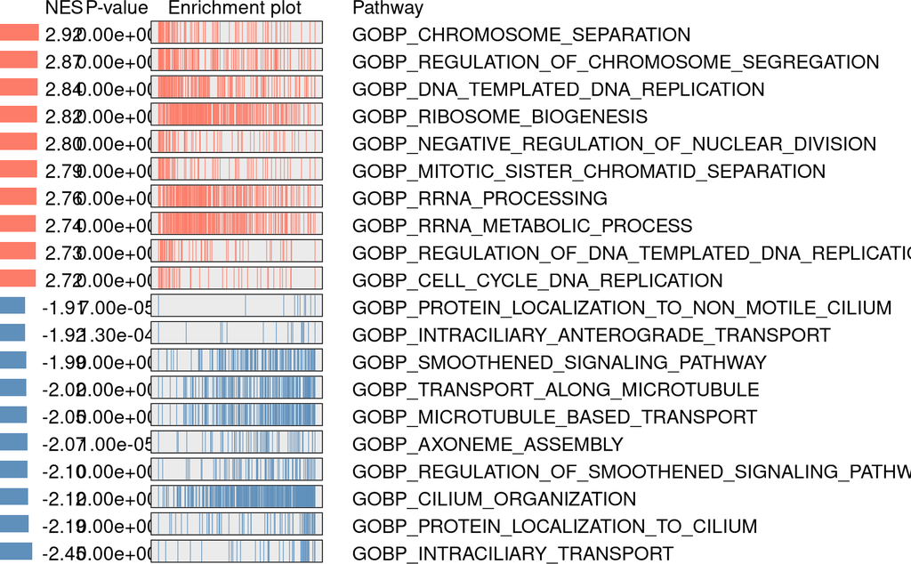

```r
heatmap <- plot_heat(
    SE_data.fgsea=SE_data.fgsea,
    strings="GOBP",
    significat_type="pval",
    topN=10,
    pathways.all=pathways.all,
    ranking.method=ranking.method)
heatmap
```

#### 4.4.2.5 Gene Ontology: molecular function

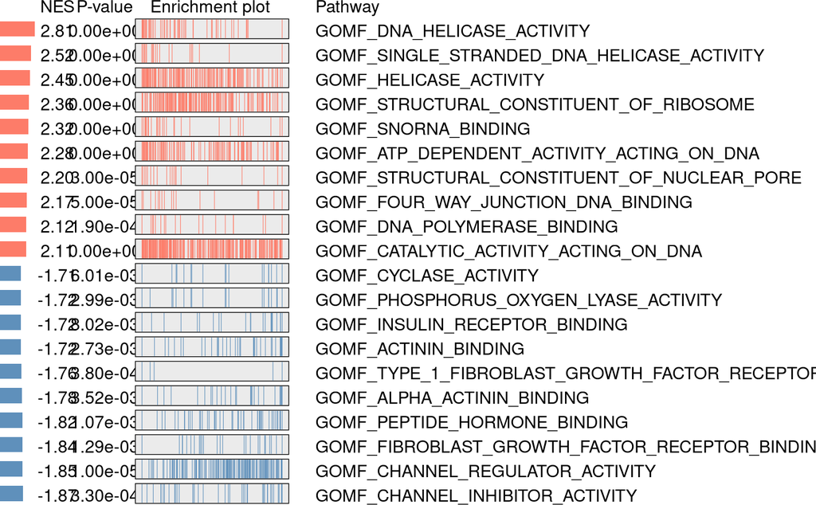

```r
heatmap <- plot_heat(
    SE_data.fgsea=SE_data.fgsea,
    strings="GOMF",
    significat_type="pval",
    topN=10,
    pathways.all=pathways.all,
    ranking.method=ranking.method)
heatmap
```

#### 4.4.2.6 Gene Ontology: cellular component

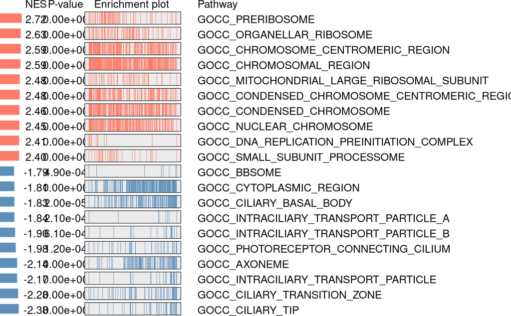

```r
heatmap <- plot_heat(
    SE_data.fgsea=SE_data.fgsea,
    strings="GOCC",
    significat_type="pval",
    topN=10,
    pathways.all=pathways.all,
    ranking.method=ranking.method)
heatmap
```

#### 4.4.2.7 Signal transduction associated function

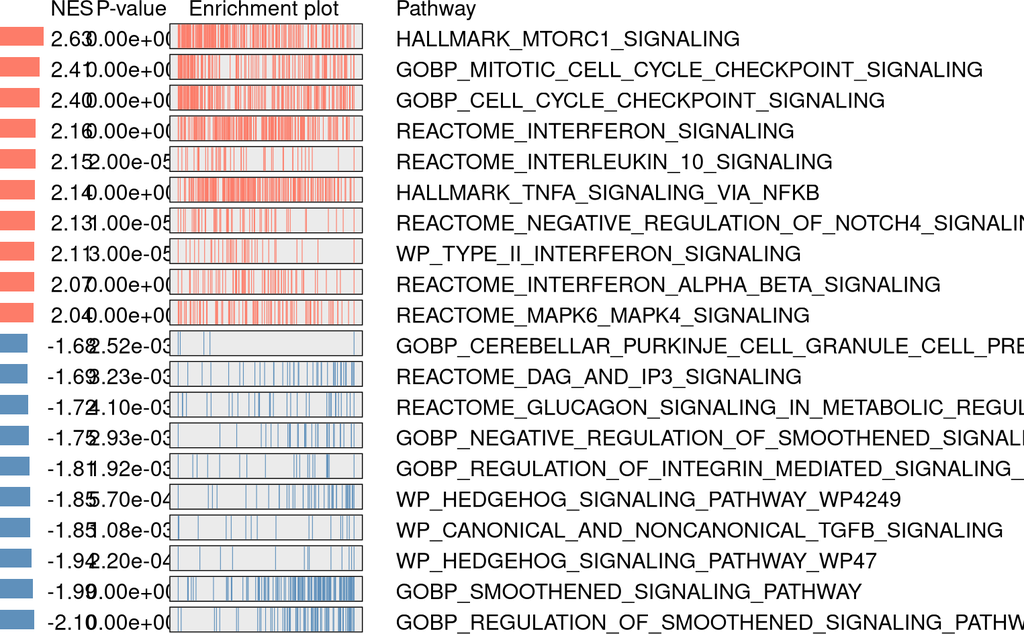

```r
heatmap <- plot_heat(
    SE_data.fgsea=SE_data.fgsea,
    strings="SIGNALING",
    significat_type="pval",
    topN=10,
    pathways.all=pathways.all,
    ranking.method=ranking.method)
heatmap
```

## 4.5 Applications of SigFun

Further applications of SigFun highlight its versatility in handling multiple types of signatures. We believe that SigFun’s general applicability enables it to analyze various signature types effectively, including immune-related signatures, drug-response signatures, and tumor-progression signatures. This broad applicability positions SigFun as a powerful resource for researchers seeking to decipher the biological functions and clinical implications of diverse gene signatures across different disease contexts.